# JSC370-slides10-ml

2024-03-11

```r
install.packages(c("rpart", "rpart.plot", "randomForest", "gbm", "xgboost"))
```

### Load packages and data

```r
library(tidyverse)
library(rpart)
library(rpart.plot)
library(randomForest)
library(gbm)
library(xgboost)
```

## Question 1: Trees with simulated data

- Simulate data from a random uniform distribution [-5,5] and normally distributed errors (s.d = 0.5)
- Create a non-linear relationship y=sin(x)+error
- Split the data into test and training sets (500 points each), plot the data

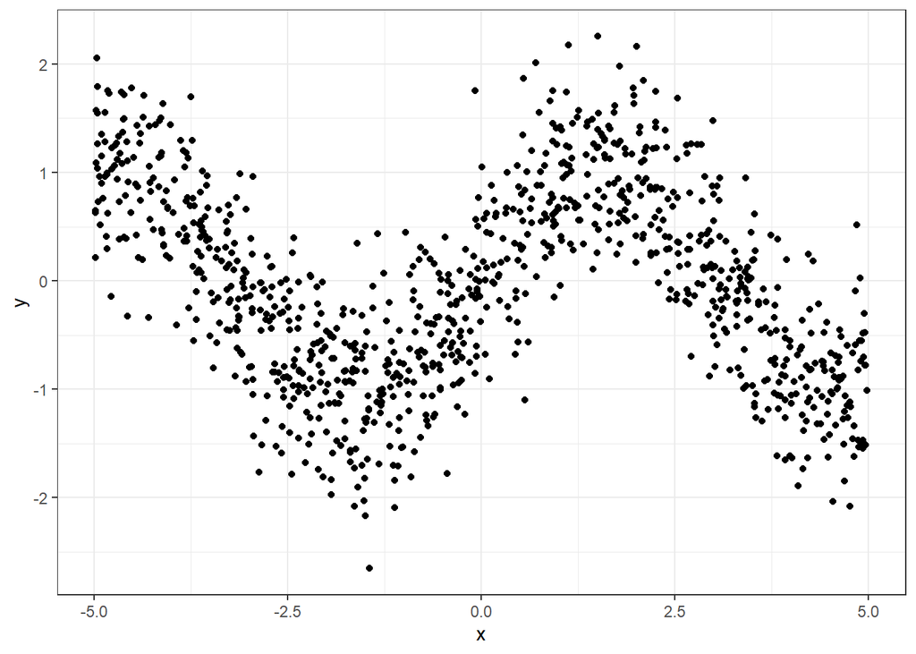

```r
set.seed(1984)
n<-1000
x<-runif(n,-5,5)
error<-rnorm(n,sd=0.5)
y<-sin(x)+error
nonlin<-data.frame(y=y, x=x)

train_size<-sample(1:1000, size = 500)
nonlin_train<-nonlin[train_size,]
nonlin_test<-nonlin[-train_size,]

ggplot(nonlin,aes(y=y,x=x))+
  geom_point() +
  theme_bw()
```

- Fit a regression tree using the training set, plot it
- Determine the optimal complexity parameter (cp) to prune the tree
- Plot the pruned tree and summarize

[figure not shown]

```r
treefit<-rpart(y~x, method = 'anova',control = list(cp=0), data = nonlin_train)
#method ='anova' indicates regression tree, cp=0 ensures that binary recursive partitioning will not stop early due to lack of improvement in RSS by an amount of at least cp

plot(treefit)
text(treefit) #annotates the tree. May fail if tree is too large
```

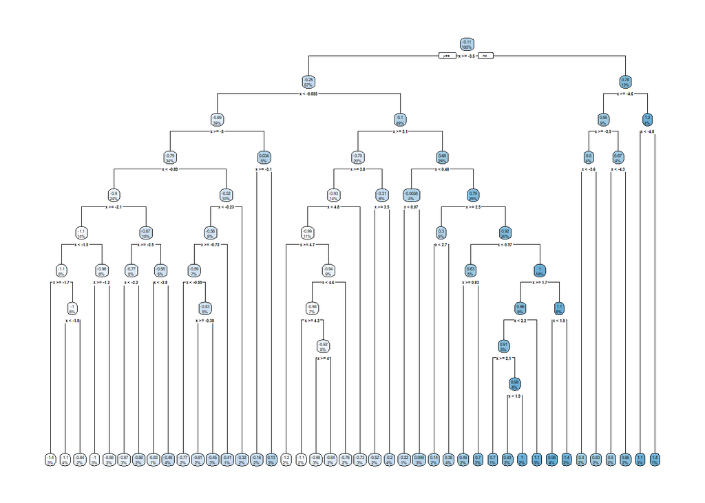

```r
rpart.plot(treefit) #rpart.plot function generates better looking trees!
```

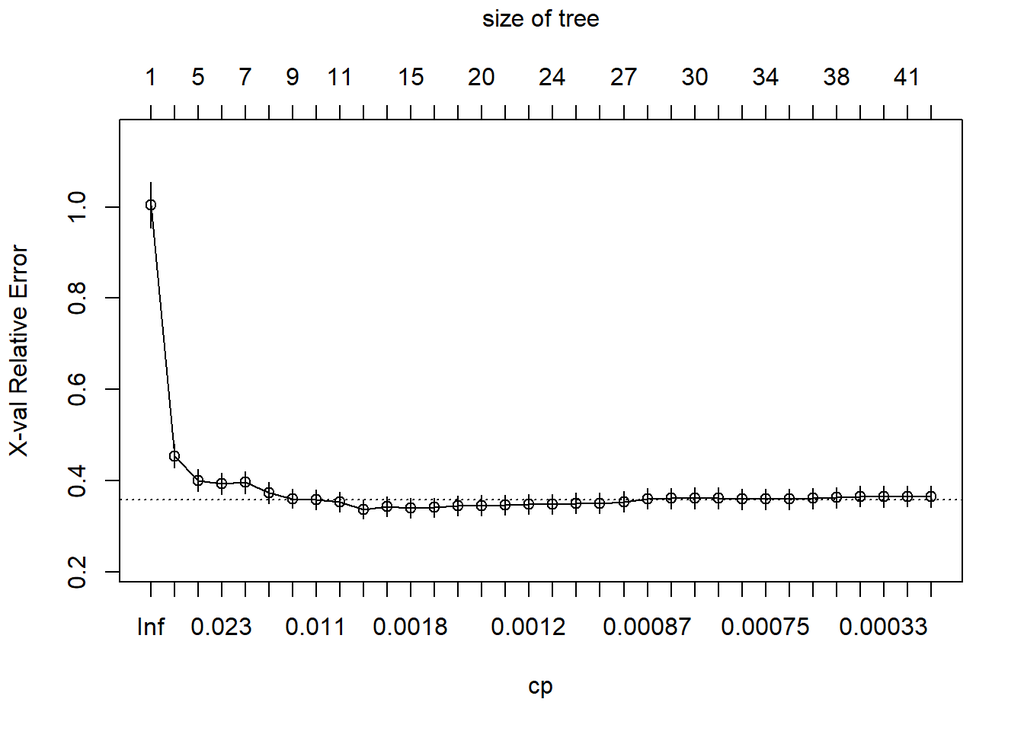

```r
# note: the height of the branches are proportional to the improvement in RSS

# plot the cp relative error to determine the optimal complexity parameter
plotcp(treefit)
```

```r
#print the table complexity parameter values and their associated cv-errors
printcp(treefit)
```

```
##
## Regression tree:
## rpart(formula = y ~ x, data = nonlin_train, method = "anova",
##     control = list(cp = 0))
##
## Variables actually used in tree construction:
## [1] x
##
## Root node error: 419.01/500 = 0.83803
##
## n= 500
##
##            CP nsplit rel error  xerror     xstd
## 1  0.19469747      0   1.00000 1.00402 0.050219
## 2  0.03406113      3   0.41591 0.45381 0.026383
```

[output cut: 32 more lines]

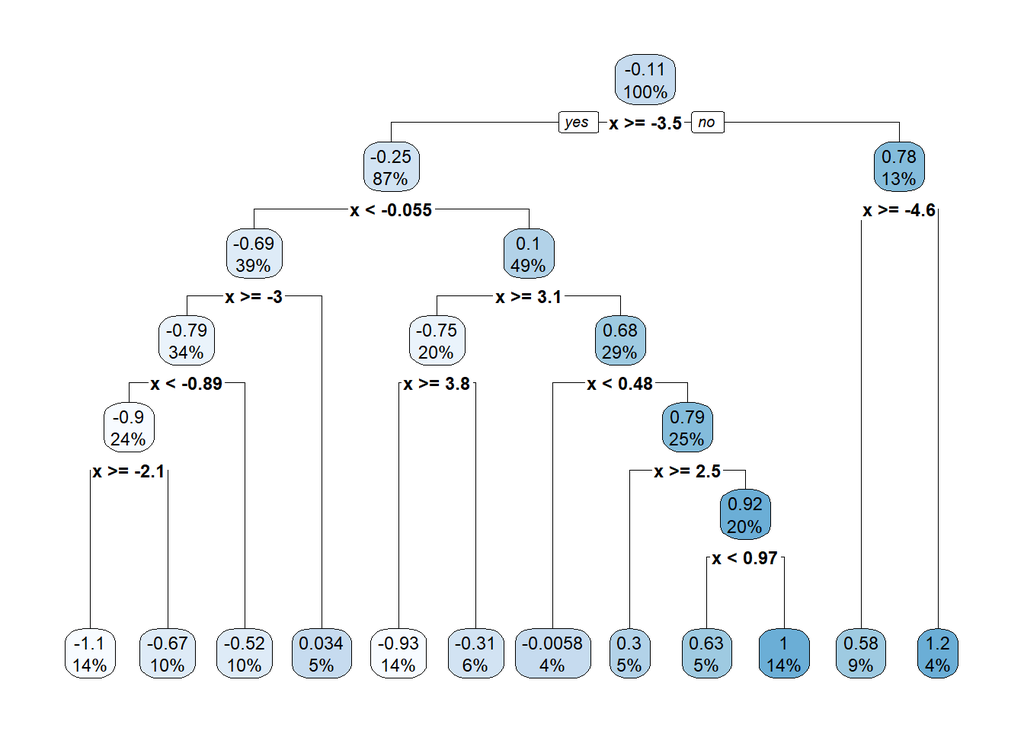

```r
# select the optimal complexity parameter and prune the tree
optimalcp<-0.0073
treepruned<-prune(treefit, cp=optimalcp)

# plot the pruned tree
rpart.plot(treepruned)
```

```r
# summarize the pruned tree object and relate the summary to the plotted tree above
summary(treepruned)
```

```
## Call:
## rpart(formula = y ~ x, data = nonlin_train, method = "anova",
##     control = list(cp = 0))
##   n= 500
##
##             CP nsplit rel error    xerror       xstd
## 1  0.194697471      0 1.0000000 1.0040153 0.05021945
## 2  0.034061135      3 0.4159076 0.4538104 0.02638272
## 3  0.027393414      4 0.3818465 0.4005153 0.02381225
## 4  0.018916616      5 0.3544530 0.3935674 0.02372447
## 5  0.018741339      6 0.3355364 0.3960865 0.02397866
## 6  0.012132319      7 0.3167951 0.3733062 0.02312415
## 7  0.011774257      8 0.3046628 0.3603378 0.02145075
## 8  0.010680660      9 0.2928885 0.3578205 0.02147093
## 9  0.007302594     10 0.2822078 0.3534446 0.02167188
## 10 0.007300000     11 0.2749053 0.3370788 0.02130490
##
## Variable importance
##   x
## 100
##
## Node number 1: 500 observations,    complexity param=0.1946975
##   mean=-0.1147421, MSE=0.8380283
##   left son=2 (436 obs) right son=3 (64 obs)
##   Primary splits:
##       x < -3.484362   to the right, improve=0.1407386, (0 missing)
##
## Node number 2: 436 observations,    complexity param=0.1946975
##   mean=-0.2463199, MSE=0.7852125
##   left son=4 (193 obs) right son=5 (243 obs)
##   Primary splits:
##       x < -0.05508361 to the left,  improve=0.1965717, (0 missing)
##
## Node number 3: 64 observations,    complexity param=0.01213232
##   mean=0.781632, MSE=0.2764066
##   left son=6 (43 obs) right son=7 (21 obs)
##   Primary splits:
##       x < -4.612867   to the right, improve=0.2873718, (0 missing)
##
## Node number 4: 193 observations,    complexity param=0.03406113
```

[output cut: 67 more lines]

```
##
## Node number 46: 26 observations
##   mean=0.3027775, MSE=0.233719
##
## Node number 47: 98 observations,    complexity param=0.007302594
##   mean=0.9238571, MSE=0.2530437
##   left son=94 (26 obs) right son=95 (72 obs)
##   Primary splits:
##       x < 0.9713606   to the left,  improve=0.1233912, (0 missing)
##
## Node number 94: 26 observations
##   mean=0.6298082, MSE=0.2488088
##
## Node number 95: 72 observations
##   mean=1.030041, MSE=0.2120744
```

- Based on the plot and/or summary of the pruned tree create a vector of the (ordered) split points for variable x, and a vector of fitted values for the intervals determined by the split points of x.

```r
# extract and sort x values at split points
x_splits <- sort(treepruned$splits[ , "index"])
# extract the corresponding y values by passing in the x values
y_splits <- predict(treepruned, data.frame(x = c(-999, x_splits)))
data.frame(x_splits_lower = c(-999, x_splits), y_fitted = y_splits)
```

```
##    x_splits_lower     y_fitted
## 1   -999.00000000  1.184925143
## 2     -4.61286694  0.584674844
## 3     -3.48436187  0.034453315
## 4     -2.95522928 -0.668074168
## 5     -2.10377810 -1.058637893
## 6     -0.88972540 -0.518359653
## 7     -0.05508361 -0.005837036
## 8      0.47826850  0.629808224
## 9      0.97136055  1.030041359
## 10     2.54085971  0.302777531
## 11     3.13346687 -0.308884110
## 12     3.81482886 -0.929044682
```

- plot the step function corresponding to the fitted (pruned) tree

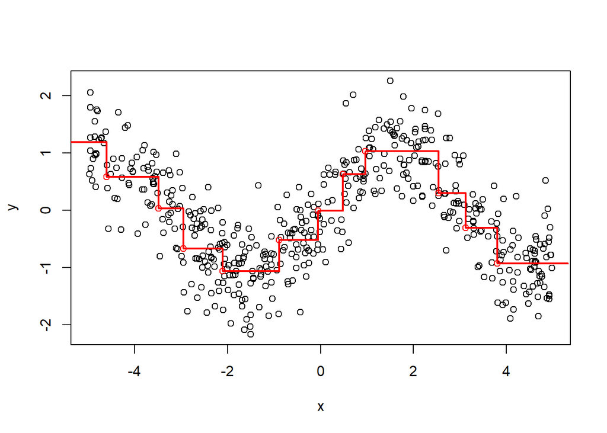

```r
stpfn <- stepfun(x_splits, y_splits)
plot(y~x, data = nonlin_train)
plot(stpfn, add = TRUE, lwd = 2, col = 'red')
```

- Fit a linear model to the training data and plot the regression line.
- Contrast the quality of the fit of the tree model vs. linear regression by inspection of the plot
- Compute the test MSE of the pruned tree and the linear regression model

```r
lmfit <- lm(y ~ x, data = nonlin_train)
summary(lmfit)
```

```
##
## Call:
## lm(formula = y ~ x, data = nonlin_train)
##
## Residuals:
##      Min       1Q   Median       3Q      Max
## -2.11037 -0.69868 -0.06587  0.68081  2.42672
##
## Coefficients:
##             Estimate Std. Error t value Pr(>|t|)
## (Intercept) -0.11249    0.04072  -2.762  0.00595 **
## x           -0.03891    0.01414  -2.752  0.00614 **
## ---
## Signif. codes:  0 '***' 0.001 '**' 0.01 '*' 0.05 '.' 0.1 ' ' 1
##
## Residual standard error: 0.9104 on 498 degrees of freedom
## Multiple R-squared:  0.01498,    Adjusted R-squared:  0.013
## F-statistic: 7.573 on 1 and 498 DF,  p-value: 0.00614
```

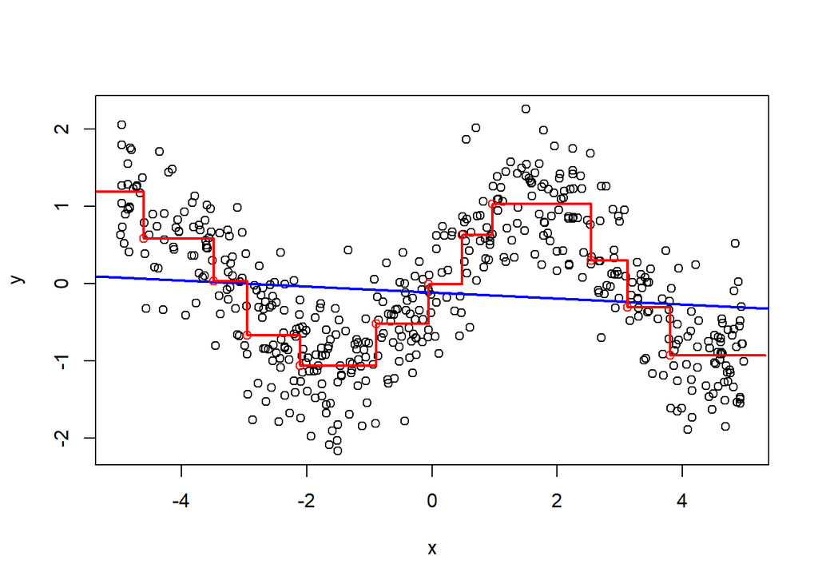

```r
plot(y ~ x, data = nonlin_train)
abline(lmfit, col = 'blue', lwd = 2)
plot(stpfn, add = TRUE, lwd = 2, col='red')
```

```r
tree_pred<-predict(treepruned, nonlin_test)
nonlin_test_tree<-cbind(nonlin_test, tree_pred)
tree_mse<-sum(nonlin_test_tree$tree_pred-nonlin_test_tree$y)^2/500
tree_mse
```

```
## [1] 0.01268992
```

```r
lm_pred<-predict(lmfit, nonlin_test)
nonlin_test_lm<-cbind(nonlin_test, lm_pred)
lm_mse<-sum(nonlin_test_lm$lm_pred-nonlin_test_lm$y)^2/500
lm_mse
```

```
## [1] 6.863004
```

- Is the lm or regression tree better at fitting a non-linear function?